# Spotify Songs Analysis

**Objective:** Analyze the Spotify dataset to uncover trends in popularity, audio features, and genres using visualizations and insights.

```python
pip install openpyxl
```

```python
import pandas as pd

# Load CSV file
df = pd.read_csv(r"D:\Spotify_Project\SpotifyFeatures.csv")

# Preview first 5 rows
df.head()
```

|  | genre | artist_name | track_name | track_id | popularity | acousticness | danceability | duration_ms | energy | instrumentalness | key | liveness | loudness | mode | speechiness | tempo | time_signature | valence |
| --- | --- | --- | --- | --- | --- | --- | --- | --- | --- | --- | --- | --- | --- | --- | --- | --- | --- | --- |
| 0 | Movie | Henri Salvador | C'est beau de faire un Show | 0BRjO6ga9RKCKjfDqeFgWV | 0 | 0.611 | 0.389 | 99373 | 0.910 | 0.000 | C# | 0.3460 | -1.828 | Major | 0.0525 | 166.969 | 4/4 | 0.814 |
| 1 | Movie | Martin & les fées | Perdu d'avance (par Gad Elmaleh) | 0BjC1NfoEOOusryehmNudP | 1 | 0.246 | 0.590 | 137373 | 0.737 | 0.000 | F# | 0.1510 | -5.559 | Minor | 0.0868 | 174.003 | 4/4 | 0.816 |
| 2 | Movie | Joseph Williams | Don't Let Me Be Lonely Tonight | 0CoSDzoNIKCRs124s9uTVy | 3 | 0.952 | 0.663 | 170267 | 0.131 | 0.000 | C | 0.1030 | -13.879 | Minor | 0.0362 | 99.488 | 5/4 | 0.368 |
| 3 | Movie | Henri Salvador | Dis-moi Monsieur Gordon Cooper | 0Gc6TVm52BwZD07Ki6tIvf | 0 | 0.703 | 0.240 | 152427 | 0.326 | 0.000 | C# | 0.0985 | -12.178 | Major | 0.0395 | 171.758 | 4/4 | 0.227 |
| 4 | Movie | Fabien Nataf | Ouverture | 0IuslXpMROHdEPvSl1fTQK | 4 | 0.950 | 0.331 | 82625 | 0.225 | 0.123 | F | 0.2020 | -21.150 | Major | 0.0456 | 140.576 | 4/4 | 0.390 |

```python
# See columns and their data types
df.info()
```

```
<class 'pandas.core.frame.DataFrame'>
RangeIndex: 232725 entries, 0 to 232724
Data columns (total 18 columns):
 #   Column            Non-Null Count   Dtype
---  ------            --------------   -----
 0   genre             232725 non-null  object
 1   artist_name       232725 non-null  object
 2   track_name        232725 non-null  object
 3   track_id          232725 non-null  object
 4   popularity        232725 non-null  int64
 5   acousticness      232725 non-null  float64
 6   danceability      232725 non-null  float64
 7   duration_ms       232725 non-null  int64
 8   energy            232725 non-null  float64
 9   instrumentalness  232725 non-null  float64
 10  key               232725 non-null  object
 11  liveness          232725 non-null  float64
 12  loudness          232725 non-null  float64
 13  mode              232725 non-null  object
 14  speechiness       232725 non-null  float64
 15  tempo             232725 non-null  float64
 16  time_signature    232725 non-null  object
 17  valence           232725 non-null  float64
dtypes: float64(9), int64(2), object(7)
memory usage: 32.0+ MB
```

```python
# Get basic statistics for numeric columns
df.describe()
```

|  | popularity | acousticness | danceability | duration_ms | energy | instrumentalness | liveness | loudness | speechiness | tempo | valence |
| --- | --- | --- | --- | --- | --- | --- | --- | --- | --- | --- | --- |
| count | 232725.000000 | 232725.000000 | 232725.000000 | 2.327250e+05 | 232725.000000 | 232725.000000 | 232725.000000 | 232725.000000 | 232725.000000 | 232725.000000 | 232725.000000 |
| mean | 41.127502 | 0.368560 | 0.554364 | 2.351223e+05 | 0.570958 | 0.148301 | 0.215009 | -9.569885 | 0.120765 | 117.666585 | 0.454917 |
| std | 18.189948 | 0.354768 | 0.185608 | 1.189359e+05 | 0.263456 | 0.302768 | 0.198273 | 5.998204 | 0.185518 | 30.898907 | 0.260065 |
| min | 0.000000 | 0.000000 | 0.056900 | 1.538700e+04 | 0.000020 | 0.000000 | 0.009670 | -52.457000 | 0.022200 | 30.379000 | 0.000000 |
| 25% | 29.000000 | 0.037600 | 0.435000 | 1.828570e+05 | 0.385000 | 0.000000 | 0.097400 | -11.771000 | 0.036700 | 92.959000 | 0.237000 |
| 50% | 43.000000 | 0.232000 | 0.571000 | 2.204270e+05 | 0.605000 | 0.000044 | 0.128000 | -7.762000 | 0.050100 | 115.778000 | 0.444000 |
| 75% | 55.000000 | 0.722000 | 0.692000 | 2.657680e+05 | 0.787000 | 0.035800 | 0.264000 | -5.501000 | 0.105000 | 139.054000 | 0.660000 |
| max | 100.000000 | 0.996000 | 0.989000 | 5.552917e+06 | 0.999000 | 0.999000 | 1.000000 | 3.744000 | 0.967000 | 242.903000 | 1.000000 |

```python
# Check which columns have missing values
df.isnull().sum()
```

```
genre               0
artist_name         0
track_name          0
track_id            0
popularity          0
acousticness        0
danceability        0
duration_ms         0
energy              0
instrumentalness    0
key                 0
liveness            0
loudness            0
mode                0
speechiness         0
tempo               0
time_signature      0
valence             0
dtype: int64
```

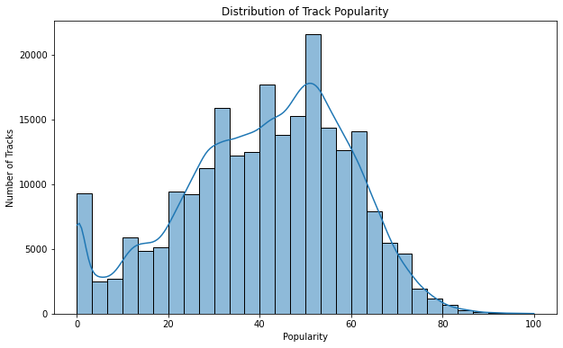

```python
#Analyze popularity

import matplotlib.pyplot as plt
import seaborn as sns

# Distribution of popularity
plt.figure(figsize=(10,6))
sns.histplot(df['popularity'], bins=30, kde=True)
plt.title('Distribution of Track Popularity')
plt.xlabel('Popularity')
plt.ylabel('Number of Tracks')
plt.show()
```

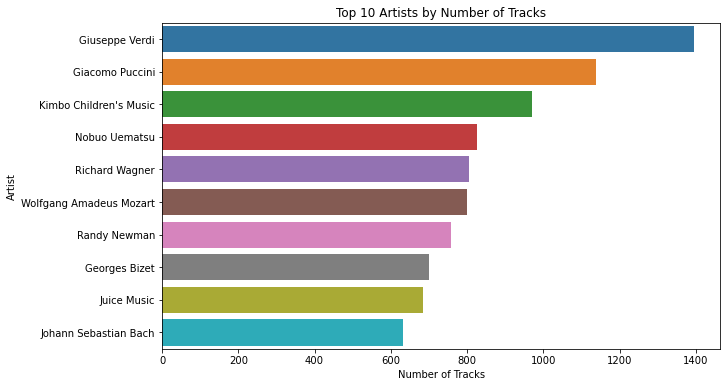

```python
##Top 10 Artists by number of tracks
top_artists = df['artist_name'].value_counts().head(10)

plt.figure(figsize=(10,6))
sns.barplot(x=top_artists.values, y=top_artists.index)
plt.title('Top 10 Artists by Number of Tracks')
plt.xlabel('Number of Tracks')
plt.ylabel('Artist')
plt.show()
```

**Analytical Question:** Which artists have the most tracks in the dataset?  
**Insight:** Artist(s) with the highest number of tracks are the most productive or consistently releasing music in the dataset.

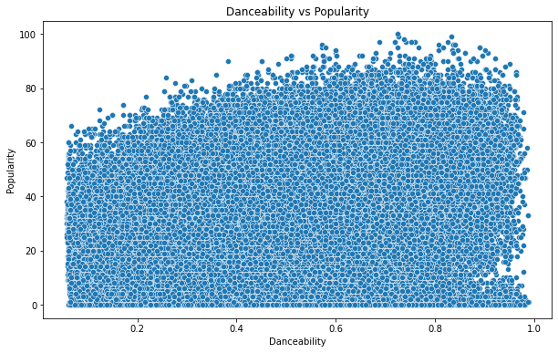

```python
#Danceability vs Popularity
plt.figure(figsize=(10,6))
sns.scatterplot(data=df, x='danceability', y='popularity')
plt.title('Danceability vs Popularity')
plt.xlabel('Danceability')
plt.ylabel('Popularity')
plt.show()
```

**Analytical Question:** How does danceability relate to popularity?  
**Insight:** Tracks with higher danceability tend to be slightly more popular, but the correlation is weak.

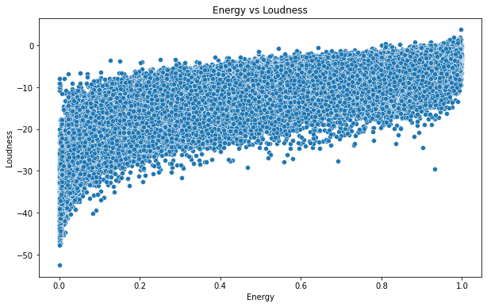

```python
#Energy vs Loudness
plt.figure(figsize=(10,6))
sns.scatterplot(data=df, x='energy', y='loudness')
plt.title('Energy vs Loudness')
plt.xlabel('Energy')
plt.ylabel('Loudness')
plt.show()
```

**Analytical Question:** Is there a relationship between a track’s energy and its loudness?  
**Insight:** Higher energy tracks are generally louder, showing that energetic songs are often produced with more intensity.

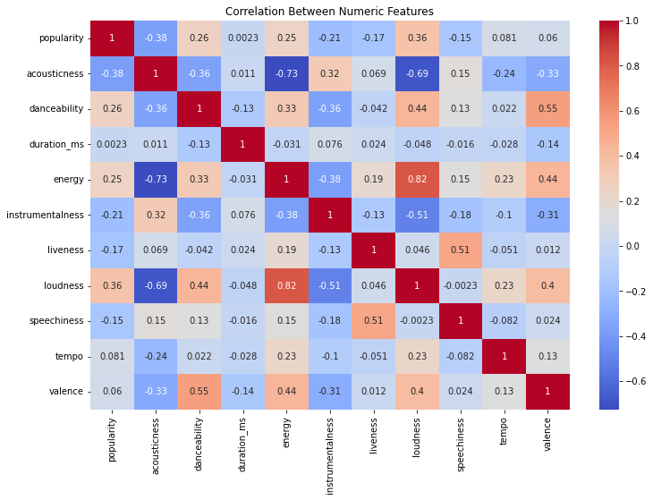

```python
#Correlation Heatmap
plt.figure(figsize=(12,8))
sns.heatmap(df.corr(), annot=True, cmap='coolwarm')
plt.title('Correlation Between Numeric Features')
plt.show()
```

**Analytical Question:** How do numeric audio features correlate with each other?  
**Insight:** Energy and loudness are strongly positively correlated; acousticness negatively correlates with loudness; valence shows moderate correlations with danceability.

```python
df.columns
```

```
Index(['genre', 'artist_name', 'track_name', 'track_id', 'popularity',
       'acousticness', 'danceability', 'duration_ms', 'energy',
       'instrumentalness', 'key', 'liveness', 'loudness', 'mode',
       'speechiness', 'tempo', 'time_signature', 'valence'],
      dtype='object')
```

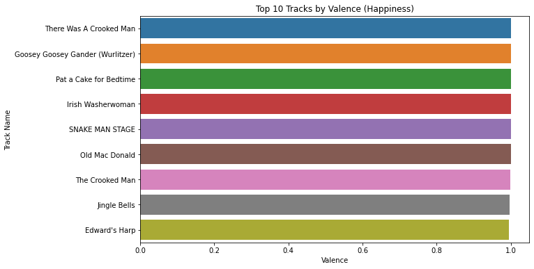

```python
top_valence = df.sort_values(by='valence', ascending=False).head(10)

plt.figure(figsize=(10,6))
sns.barplot(x='valence', y='track_name', data=top_valence)
plt.title('Top 10 Tracks by Valence (Happiness)')
plt.xlabel('Valence')
plt.ylabel('Track Name')
plt.show()
```

**Analytical Question:** Which tracks are the happiest (most positive)?  
**Insight:** Tracks with the highest valence are the happiest; valence measures musical positivity.

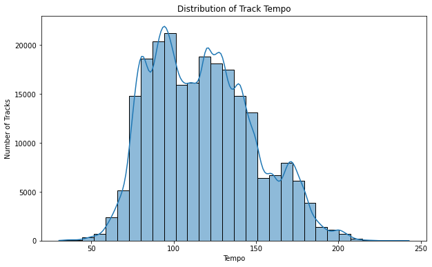

```python
#Tempo Distribution
plt.figure(figsize=(10,6))
sns.histplot(df['tempo'], bins=30, kde=True)
plt.title('Distribution of Track Tempo')
plt.xlabel('Tempo')
plt.ylabel('Number of Tracks')
plt.show()
```

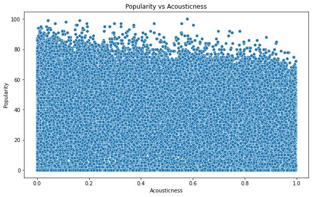

```python
#Popularity vs Acousticness
plt.figure(figsize=(10,6))
sns.scatterplot(data=df, x='acousticness', y='popularity')
plt.title('Popularity vs Acousticness')
plt.xlabel('Acousticness')
plt.ylabel('Popularity')
plt.show()
```

**Analytical Question:** Does acousticness affect track popularity?  
**Insight:** Tracks with higher acousticness tend to be slightly less popular, suggesting listeners favor more energetic or electronic sounds.

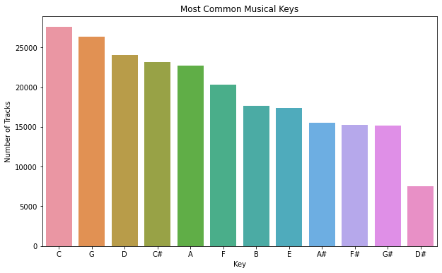

```python
#Most Common Musical Keys
key_counts = df['key'].value_counts()

plt.figure(figsize=(10,6))
sns.barplot(x=key_counts.index, y=key_counts.values)
plt.title('Most Common Musical Keys')
plt.xlabel('Key')
plt.ylabel('Number of Tracks')
plt.show()
```

**Analytical Question:** Which keys are most frequently used in tracks?  
**Insight:** Keys 0 (C) and 7 (G) are most common, indicating these keys are favored for composition.

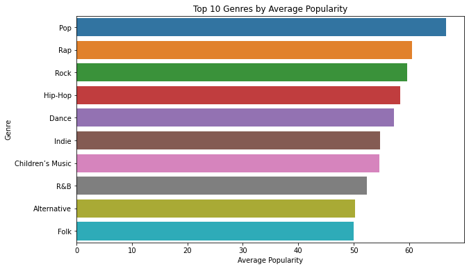

```python
#Top 10 Genres by Average Popularity
top_genres = df.groupby('genre')['popularity'].mean().sort_values(ascending=False).head(10)

plt.figure(figsize=(10,6))
sns.barplot(x=top_genres.values, y=top_genres.index)
plt.title('Top 10 Genres by Average Popularity')
plt.xlabel('Average Popularity')
plt.ylabel('Genre')
plt.show()
```

**Analytical Question:** Which genres have the highest average popularity?  
**Insight:** Certain genres dominate in popularity (e.g., Pop or Hip-Hop), reflecting listener preferences in the dataset.